# Explorer la dépression

Nour Sfar

2023-04-29

# I. Introduction:

- Objectif : L’ACP (Analyse en composantes principales) et l’ACM (Analyse des Correspondances Multiples) sont des méthodes pertinentes pour l’analyse des données et la statistique multivariée. On va adopter ces méthodes pour analyser notre base de donnée. Puis faire une classification pour expliquer la carte des individus.

# II. Découvrir la base de données:

- Colonne1 :est une variable qualitative qui représente le sexe.
- Colonne2 : est une variable qualitative ordinale qui représente les classes d’âge.
- Colonne 3 à 5 : se sont des variables qualtitatives qui représentent la classe socio-professionnelle, type de lycée(pour les lycéens) et filière d’étude(pour les etudiants).

Le reste des colonnes sont partitionné en quatres blocs:

- Deux blocs de variables ont été obtenus à partir de questions à réponse binaire (oui/non).
- Deux blocs de variables comportant soit des symptômes, soit des habitudes ont été obtenus à partir d’une échelle de Likert graduée de 1 à 5.

# Importer et préparer le jeu de données:

```r
df<-read_csv("Explorer La Dépression.csv", show_col_types = FALSE)
names(df)=c("submission_time","genre","âge","CSP","Type_lycée","Filière_étude",
            "Dépression_ressentie","Dépression_diagnostiquée",
            "Consultation_dépression","Antécédents_familiaux_dépression",
            "Maladie_physique","Antécédents_stress","Changements_alimentaires",
            "Troubles_sommeil","Fatigue/mnq_energie","Manque_motivation",
            "Difficulté_concentration","Sentiments_culpabilité/dévalorisation",
            "Perte_confiance-soi","Idées_suicidaires","Trouble_humeur",
            "Agitation/Ralentissement_Psychomoteur","Sentiments_vide/solitude",
            "Désintérêt_activités","Douleurs_inexpliqués","Problèmes_mémoire",
            "Sentiments_désespoir","Manque_émotions","Appétit_poids",
            "Isolement_social","TOC","Perte_intérêt/plaisir","Vidéos_démotivantes",
            "Traitement_médical","Fumer","Buver_alcool","Cons_drogue",
            "Diff_financières/logement","Traitement+effets_secondaires",
            "Diff_relationnelles/familiales","diff_scolaires/professionnelles",
            "Problèmes_santé_physique", "Arrêt_relation_amoureuse","Accident",
            "Evénement_stressant","Troubles_stress","comments")
df[df=="Jamais"]<-'0'
df[df=="Rarement"]<-'1'
df[df=="Parfois"]<-'2'
df[df=="fréquemment"]<-'3'
df[df=="Fréquemment"]<-'3'
df[df=="Presque toujours"]<-'4'
bloc1<-df[,13:32]
bloc2<-df[,33:42]
sapply(bloc1, class)
```

```
##              Changements_alimentaires                      Troubles_sommeil
##                           "character"                           "character"
##                   Fatigue/mnq_energie                     Manque_motivation
##                           "character"                           "character"
##              Difficulté_concentration Sentiments_culpabilité/dévalorisation
##                           "character"                           "character"
##                   Perte_confiance-soi                     Idées_suicidaires
##                           "character"                           "character"
##                        Trouble_humeur Agitation/Ralentissement_Psychomoteur
##                           "character"                           "character"
##              Sentiments_vide/solitude                  Désintérêt_activités
##                           "character"                           "character"
##                  Douleurs_inexpliqués                     Problèmes_mémoire
##                           "character"                           "character"
##                  Sentiments_désespoir                       Manque_émotions
##                           "character"                           "character"
##                         Appétit_poids                      Isolement_social
##                           "character"                           "character"
##                                   TOC                 Perte_intérêt/plaisir
##                           "character"                           "character"
```

```r
sapply(bloc2, class)
```

```
##             Vidéos_démotivantes              Traitement_médical
##                     "character"                     "character"
##                           Fumer                    Buver_alcool
##                     "character"                     "character"
##                     Cons_drogue       Diff_financières/logement
##                     "character"                     "character"
##   Traitement+effets_secondaires  Diff_relationnelles/familiales
##                     "character"                     "character"
## diff_scolaires/professionnelles        Problèmes_santé_physique
##                     "character"                     "character"
```

```r
bloc1<-sapply(bloc1, as.numeric)
bloc2<-sapply(bloc2, as.numeric)
bloc1<-as.data.frame(bloc1)
bloc2<-as.data.frame(bloc2)
```

# 1.Explorer le jeu de données

```r
summary(df)
```

```
##  submission_time       genre               âge                CSP
##  Length:126         Length:126         Length:126         Length:126
##  Class :character   Class :character   Class :character   Class :character
##  Mode  :character   Mode  :character   Mode  :character   Mode  :character
##   Type_lycée        Filière_étude      Dépression_ressentie
##  Length:126         Length:126         Length:126
##  Class :character   Class :character   Class :character
##  Mode  :character   Mode  :character   Mode  :character
##  Dépression_diagnostiquée Consultation_dépression
##  Length:126               Length:126
##  Class :character         Class :character
##  Mode  :character         Mode  :character
##  Antécédents_familiaux_dépression Maladie_physique   Antécédents_stress
##  Length:126                       Length:126         Length:126
##  Class :character                 Class :character   Class :character
##  Mode  :character                 Mode  :character   Mode  :character
##  Changements_alimentaires Troubles_sommeil   Fatigue/mnq_energie
##  Length:126               Length:126         Length:126
##  Class :character         Class :character   Class :character
##  Mode  :character         Mode  :character   Mode  :character
##  Manque_motivation  Difficulté_concentration
##  Length:126         Length:126
##  Class :character   Class :character
##  Mode  :character   Mode  :character
##  Sentiments_culpabilité/dévalorisation Perte_confiance-soi Idées_suicidaires
##  Length:126                            Length:126          Length:126
##  Class :character                      Class :character    Class :character
##  Mode  :character                      Mode  :character    Mode  :character
##  Trouble_humeur     Agitation/Ralentissement_Psychomoteur
##  Length:126         Length:126
##  Class :character   Class :character
##  Mode  :character   Mode  :character
##  Sentiments_vide/solitude Désintérêt_activités Douleurs_inexpliqués
##  Length:126               Length:126           Length:126
##  Class :character         Class :character     Class :character
##  Mode  :character         Mode  :character     Mode  :character
##  Problèmes_mémoire  Sentiments_désespoir Manque_émotions    Appétit_poids
##  Length:126         Length:126           Length:126         Length:126
##  Class :character   Class :character     Class :character   Class :character
##  Mode  :character   Mode  :character     Mode  :character   Mode  :character
```

[output cut: 9 more lines]

```
##  Length:126         Length:126                Length:126
##  Class :character   Class :character          Class :character
##  Mode  :character   Mode  :character          Mode  :character
##  Diff_relationnelles/familiales diff_scolaires/professionnelles
##  Length:126                     Length:126
##  Class :character               Class :character
##  Mode  :character               Mode  :character
##  Problèmes_santé_physique Arrêt_relation_amoureuse   Accident
##  Length:126               Length:126               Length:126
##  Class :character         Class :character         Class :character
##  Mode  :character         Mode  :character         Mode  :character
##  Evénement_stressant Troubles_stress      comments
##  Length:126          Length:126         Length:126
##  Class :character    Class :character   Class :character
##  Mode  :character    Mode  :character   Mode  :character
```

# 2.Analyse Descriptiv des Données:

### 2.1.Répartition par genre:

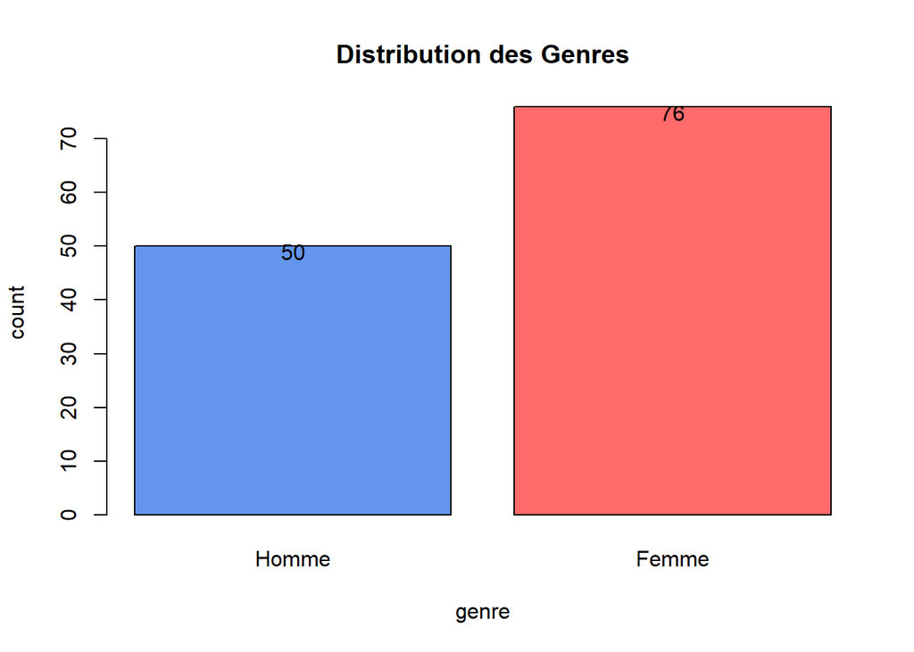

```r
df$genre <-  factor(df$genre, levels = c('Homme', 'Femme'))
#Plot Homme/Femme
p1 <- plot(df$genre, main = 'Distribution des Genres', xlab = 'genre', ylab = 'count', col = c('cornflowerblue', 'indianred1'))
text(p1[,1],table(df$genre)-1,table(df$genre))
```

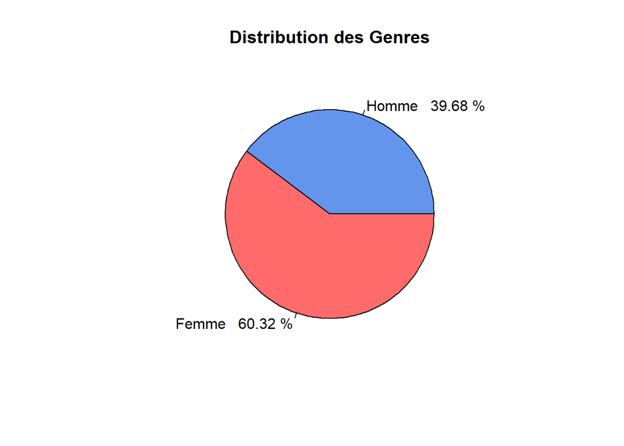

```r
#Camembert Homme/Femme
df['genre'] %>%
  group_by(genre) %>%
  summarize(count = n()) -> d
pct = d$count / sum(d$count) * 100
p2 <- pie(d$count, labels = paste(d$genre,' ', round(pct, 2), '%' ), col = c('cornflowerblue', 'indianred1'),
          main = 'Distribution des Genres')
```

**Interprétation :**

- A l’issue de ce questionnaire, on a 60.32% des réponses sont des femmes (76 femmes), 39.68% sont des Hommes (50 hommes).

### 2.2.Répartition par âge :

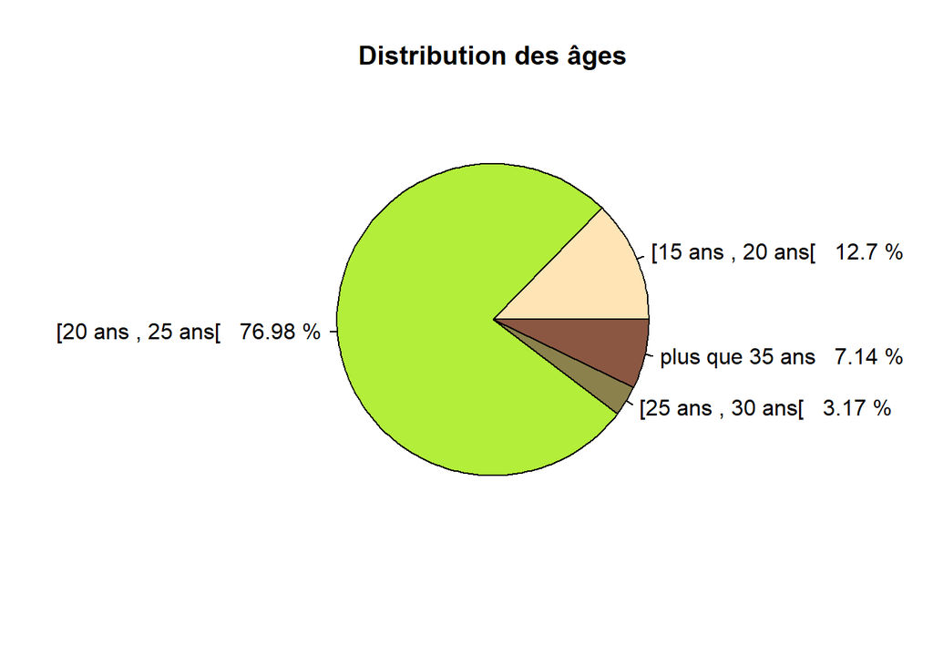

```r
#Camembert âges
df['âge'] %>%
  group_by(âge) %>%
  summarize(count = n()) -> d
pct = d$count / sum(d$count) * 100
p4 <- pie(d$count, labels = paste(d$âge,' ', round(pct, 2), '%' ), col = c('moccasin', 'olivedrab2', 'lightgoldenrod4','lightsalmon4'),
          main = 'Distribution des âges')
```

**Interprétation :**

- On remarque que la tranche d’âge majoritaire dans notre échantillon est du 20 ans à 25 ans.

### 2.3.Répartition par catégorie socioprofessionnelle :

[figure not shown]

```r
#Plot CSP
ll=c("étudiant(e)","à la recherche d'un emploi","lycéen(ne)","étudiant(e)+ employé(e) à mi-temps","retraité(e)","employé(e) ")
df$CSP <- factor(df$CSP, levels = unique(df$CSP))
p5 <- plot(df$CSP, main = 'Distribution des CSP', xlab = 'status', ylab = 'count', col = c('coral2', 'aquamarine3', 'dodgerblue2', 'yellow', 'azure3', 'brown3', 'gray43'))
legend(x="top",legend=ll,fill=c('coral2', 'aquamarine3', 'dodgerblue2', 'yellow', 'azure3', 'brown3', 'gray43'),bty="n")
```

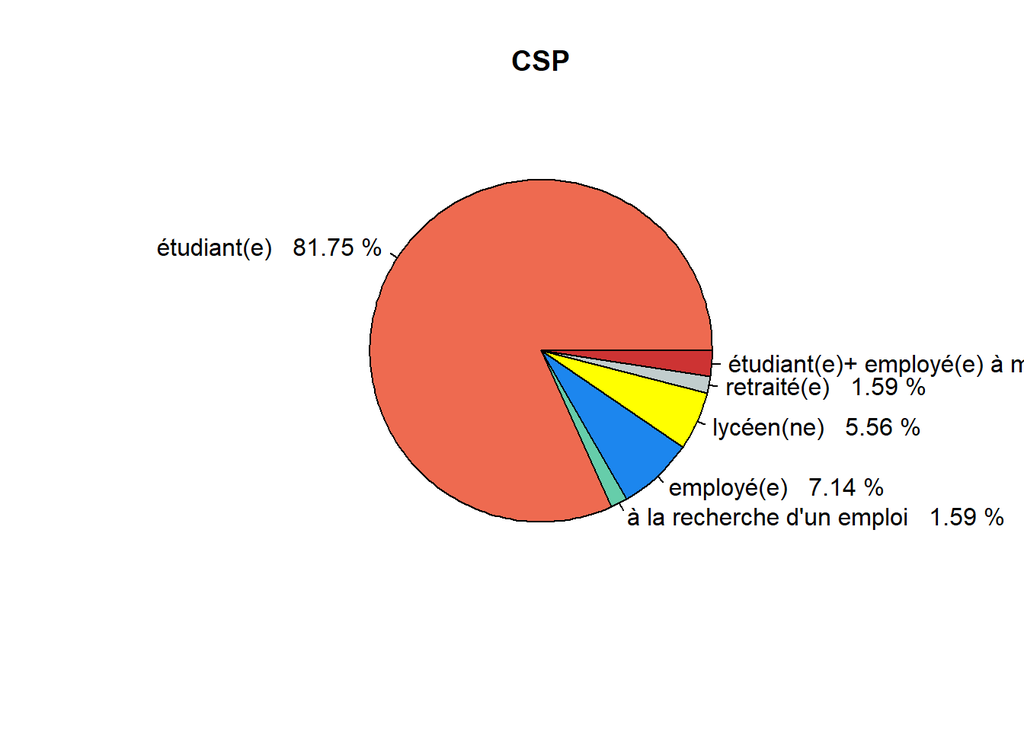

```r
#Camembert CSP
df['CSP'] %>%
  group_by(CSP) %>%
  summarize(count = n()) -> d
pct = d$count / sum(d$count) * 100
p6 <- pie(d$count, labels = paste(d$CSP,' ', round(pct, 2), '%' ), col = c('coral2', 'aquamarine3', 'dodgerblue2', 'yellow', 'azure3', 'brown3', 'gray43'),
          main = 'CSP')
```

**Interprétation :**

- Les Etudiants sont les majoritaires dans notre échantillon avec un ratio qui dépasse les 80% des individus le l’échantillon.

### 2.4.Répartition des étudiants par filière d’étude :

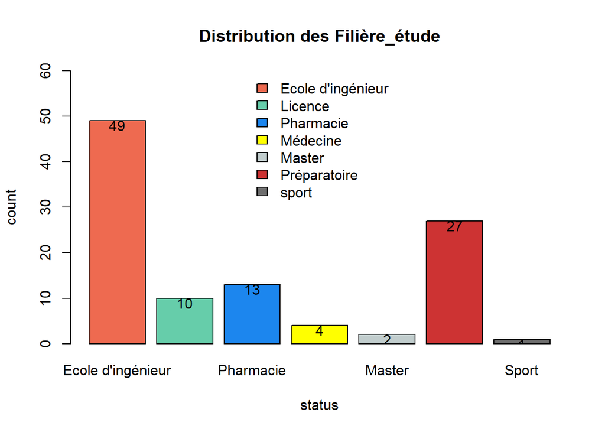

```r
#Plot Filière_étude
ll=c("Ecole d'ingénieur","Licence","Pharmacie","Médecine","Master","Préparatoire","sport")
db <- df %>%
  filter(Filière_étude != '')
db$Filière_étude <- factor(db$Filière_étude, levels = unique(db$Filière_étude))
p7 <- plot(db$Filière_étude, main = 'Distribution des Filière_étude', xlab = 'status', ylab = 'count', col = c('coral2', 'aquamarine3', 'dodgerblue2', 'yellow', 'azure3', 'brown3', 'gray43'),ylim=c(0,60))
legend(x="top",legend=ll,fill=c('coral2', 'aquamarine3', 'dodgerblue2', 'yellow', 'azure3', 'brown3', 'gray43'),bty="n")
text(p7[,1],table(db$Filière_étude)-1,table(db$Filière_étude))
```

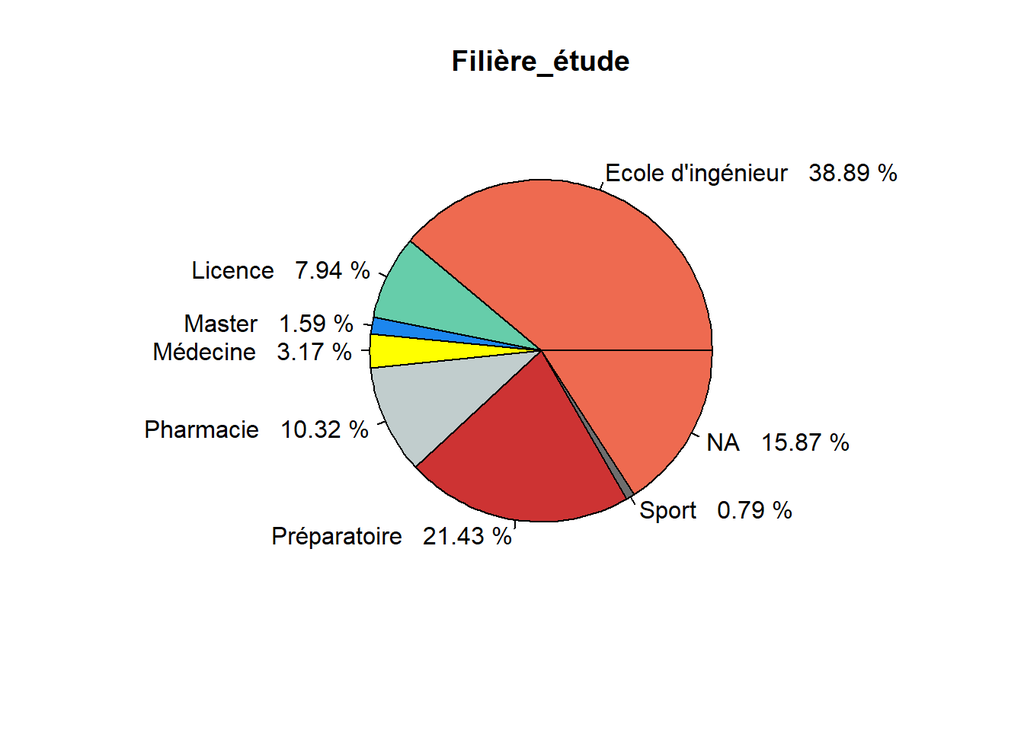

```r
#Camembert Filière_étude
df['Filière_étude'] %>%
  group_by(Filière_étude) %>%
  summarize(count = n()) -> d
pct = d$count / sum(d$count) * 100
p8 <- pie(d$count, labels = paste(d$Filière_étude,' ', round(pct, 2), '%' ), col = c('coral2', 'aquamarine3', 'dodgerblue2', 'yellow', 'azure3', 'brown3', 'gray43'),
          main = 'Filière_étude')
```

**Interprétation :**

- On remarque que la filière qui perciste dans notre échantillon c’est le cycle ingénieur (Préparatoire + Ecole d’ing) avec un ratio qui dépasse les 60% de l’échantillon.
- 15.87% des individus de notre échantillon sont pas des étudiants.

### 2.5.Quelques Comportement des individus :

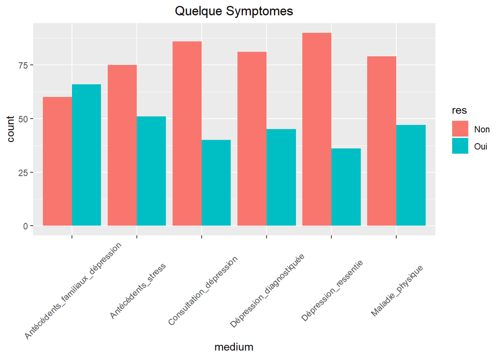

```r
l1 <- list(medium = rep(c("Dépression_ressentie", "Dépression_diagnostiquée", "Consultation_dépression", "Antécédents_familiaux_dépression", "Maladie_physique","Antécédents_stress"),
                       each = length(df[,1])), res = c(df$Dépression_ressentie, df$Dépression_diagnostiquée, df$Consultation_dépression,
                                                         df$Antécédents_familiaux_dépression, df$Maladie_physique, df$Antécédents_stress))
data1 <- data.frame(l1)
ggplot(data1, aes(medium, fill = res)) +
  geom_bar(position = 'dodge') +
  labs(title = 'Quelque Symptomes', x = 'medium') +
  theme(plot.title = element_text(hjust = 0.5),
        axis.text.x = element_text(angle = 45, vjust = 0.5)
  ) -> p9
p9
```

### 2.6.Quelques événements peuvent arriver aux individus :

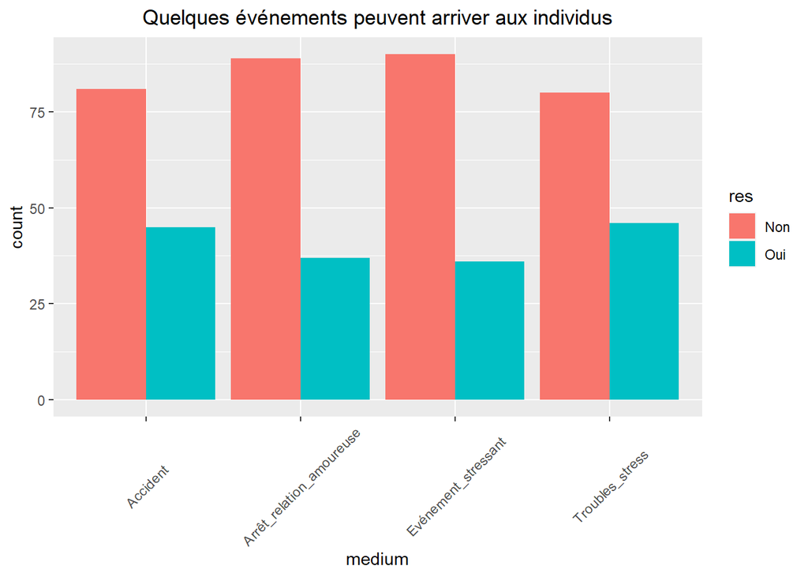

```r
l2 <- list(medium = rep(c("Arrêt_relation_amoureuse", "Accident", "Evénement_stressant", "Troubles_stress"),
                        each = length(df[,1])), res = c(df$Arrêt_relation_amoureuse, df$Accident, df$Evénement_stressant,df$Troubles_stress))
data2 <- data.frame(l2)
ggplot(data2, aes(medium, fill = res)) +
  geom_bar(position = 'dodge') +
  labs(title = 'Quelques événements peuvent arriver aux individus', x = 'medium') +
  theme(plot.title = element_text(hjust = 0.5),
        axis.text.x = element_text(angle = 45, vjust = 0.5)
  ) -> p10
p10
```

# III. ACP et son interprétation :

- L’ACP est une technique d’analyse multivariée qui permet de réduire la dimensionnalité d’un ensemble de variables tout en préservant au maximum l’information qu’elles contiennent.
- Dans notre cas l’ACP pourrait être utilisée pour identifier les variables qui sont les plus importantes pour décrire les symptômes de la dépression et pour trouver des groupes de symptômes qui se regroupent souvent ensemble.

## 1. But de l’ACP :

- Variables : Regrouper les variables correlées et les remplacer par un petit nombre de nouvelles variables qui sont les composantes principales décrivant symptomes ou les causes de la dépression.
- Individus : Regrouper les individus qui ont les mêmes symptômes ou mêmes habitues et indiquer les symptômes et les habitudes qui les caractérisent.

## 2. Pertinence de l’ACP:

### 2.1. Critère 1: Le Corrplot:

- Le corrgram donné ci-dessous permet d’étudier les corrélations entre les variables quantitatives.

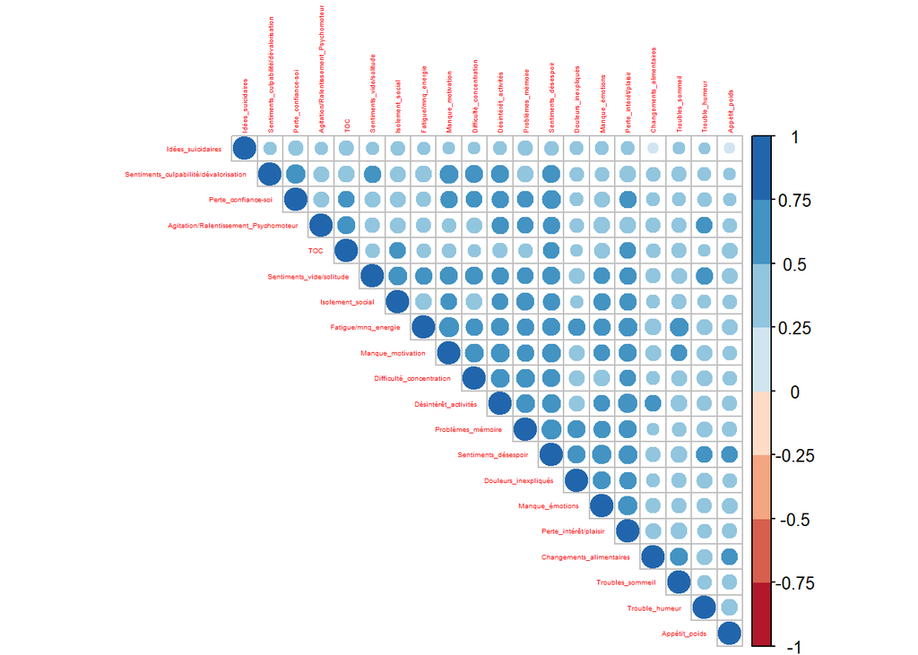

```r
m1<-cor(bloc1)

correlations <- corrplot(m1, type="upper", order="hclust",
                         col=brewer.pal(n=8, name="RdBu"),tl.cex = 0.3)
```

```r
res.pca=PCA(bloc1, ncp = 10, graph = F)
```

**Interprétation :**

- Il est clair qu’il existe des corrélations importantes entre des groupes de variables ce qui suggère la pertinence de cette ACP.

### 2.2. Critère 2: Les Valeurs Propres:

```r
val_prop <- res.pca$eig
head(val_prop)
```

```
##        eigenvalue percentage of variance cumulative percentage of variance
## comp 1 10.2116342              51.058171                          51.05817
## comp 2  1.2022522               6.011261                          57.06943
## comp 3  1.0945357               5.472678                          62.54211
## comp 4  0.9624822               4.812411                          67.35452
## comp 5  0.7663093               3.831547                          71.18607
## comp 6  0.7298598               3.649299                          74.83537
```

**Interprétation :**

- Une valeur très élevée a été obtenue pour la première valeur propre.

## 3.Choix du nombre d’axes à retenir :

### 3.1 Crirère de Kaiser :

```r
val_prop[,1]
```

```
##     comp 1     comp 2     comp 3     comp 4     comp 5     comp 6     comp 7
## 10.2116342  1.2022522  1.0945357  0.9624822  0.7663093  0.7298598  0.6805018
##     comp 8     comp 9    comp 10    comp 11    comp 12    comp 13    comp 14
##  0.5892378  0.5173245  0.4961391  0.4303420  0.3834948  0.3520654  0.3314169
##    comp 15    comp 16    comp 17    comp 18    comp 19    comp 20
##  0.2668980  0.2453968  0.2251123  0.1893941  0.1666464  0.1589565
```

### 3.2 Critère du Taux d’Inertie Cumulée :

```r
val_prop[,3]
```

```
##    comp 1    comp 2    comp 3    comp 4    comp 5    comp 6    comp 7    comp 8
##  51.05817  57.06943  62.54211  67.35452  71.18607  74.83537  78.23788  81.18407
##    comp 9   comp 10   comp 11   comp 12   comp 13   comp 14   comp 15   comp 16
##  83.77069  86.25138  88.40309  90.32057  92.08089  93.73798  95.07247  96.29945
##   comp 17   comp 18   comp 19   comp 20
##  97.42501  98.37199  99.20522 100.00000
```

**Interprétation :**

- On remarque que le `taux d'inertie cumulé` des deux premiers axes est de 57.06943% qui est un taux importantcompte tenu du fait que nous avons 20 variables : on va donc, d’parès le critère du taux d’inertie cumulé, rtenir les 2 premiers axes.

### 3.3 Critère du Coude :

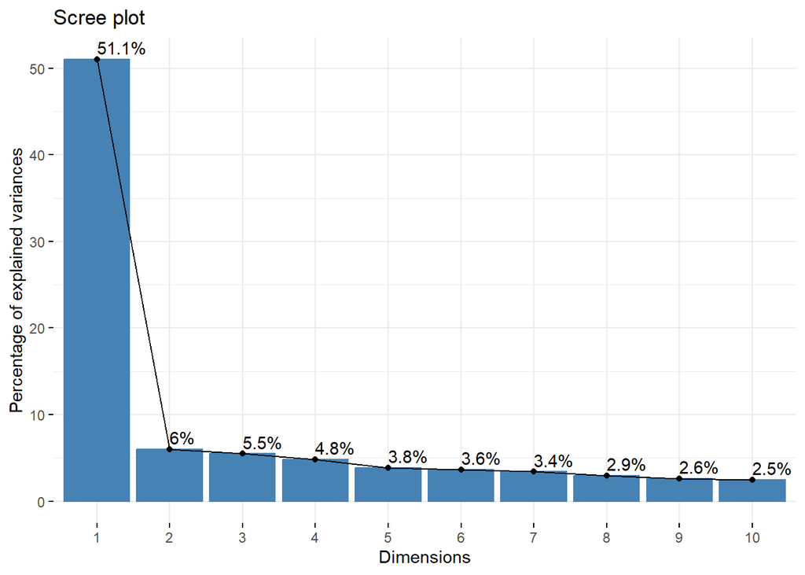

```r
fviz_screeplot(res.pca,addlabels=TRUE)
```

**Interprétation :**

- On remarque que le coude se trouve au nivaux du du deuxième axe, d’après le `Critère du Coude`, on devrait retenir les 2 premiers axes.

### 3.4. Axes à retenir :

- On peut conclure par vote des 3 criteres qu’on devrait retenir les `2 premiers axes`.

## 4.Interprétation de la carte des variables :

### 4.1. Coordonnées des variables :

- L’objet `var` de `res.pca` contient les 4 objets : `coord`, `cor`, `cos2` et `contrib`.
- A noter que vu que notre ACP est normée, cor (i.e. la corrélations d’une variable avec la composante principale d’un axe) est identique à coord (i.e. la coordonnée de cette variable sur cet axe).

```r
names(res.pca$var)
```

```
## [1] "coord"   "cor"     "cos2"    "contrib"
```

- L’objet `coord` dans `var` contient les coordonnées des variables.

```r
res.pca$var$coord
```

```
##                                           Dim.1        Dim.2       Dim.3
## Changements_alimentaires              0.6192530  0.458416825  0.25613281
## Troubles_sommeil                      0.6756491  0.344732949  0.11026914
## Fatigue/mnq_energie                   0.7780426  0.247502409 -0.14275928
## Manque_motivation                     0.7842850  0.057647175 -0.29590996
## Difficulté_concentration              0.7475262 -0.049331685 -0.38829589
## Sentiments_culpabilité/dévalorisation 0.7199256 -0.282408932 -0.10301719
## Perte_confiance-soi                   0.7100421 -0.416248810  0.01697140
## Idées_suicidaires                     0.5000128 -0.400099580  0.22122254
## Trouble_humeur                        0.6376272  0.316998646 -0.01576050
## Agitation/Ralentissement_Psychomoteur 0.6812892 -0.057290846  0.34509613
## Sentiments_vide/solitude              0.7515305  0.064088155 -0.15469836
## Désintérêt_activités                  0.7982838 -0.041299397 -0.13795917
## Douleurs_inexpliqués                  0.6687030  0.127905321 -0.20229106
## Problèmes_mémoire                     0.7730520 -0.165983066 -0.20834087
## Sentiments_désespoir                  0.8491699 -0.100774088 -0.07671791
## Manque_émotions                       0.7468186 -0.003043481  0.07381884
## Appétit_poids                         0.6172891  0.383297714  0.28642046
## Isolement_social                      0.7137570 -0.176784159  0.12093041
## TOC                                   0.6355906 -0.222024513  0.58536257
## Perte_intérêt/plaisir                 0.7931549 -0.045064495  0.03064487
##                                             Dim.4       Dim.5        Dim.6
## Changements_alimentaires              -0.25151194 -0.09820315  0.111214551
## Troubles_sommeil                      -0.18428885 -0.32031267  0.171763219
## Fatigue/mnq_energie                   -0.03026339 -0.27443929  0.074001096
## Manque_motivation                     -0.22894724 -0.10567574 -0.014584001
## Difficulté_concentration              -0.07737154  0.12569081 -0.027402597
## Sentiments_culpabilité/dévalorisation -0.45908827  0.06278539  0.086364286
## Perte_confiance-soi                   -0.23930445  0.09406268  0.110731194
## Idées_suicidaires                      0.27720883 -0.16060307  0.443632934
## Trouble_humeur                         0.07754715  0.52282528  0.170872060
## Agitation/Ralentissement_Psychomoteur -0.05333015  0.27848960  0.086846041
## Sentiments_vide/solitude              -0.06901408  0.09835273 -0.266280551
## Désintérêt_activités                  -0.10131827 -0.06036102  0.021250951
## Douleurs_inexpliqués                   0.41428759 -0.05861052  0.269993214
## Problèmes_mémoire                      0.27365530  0.11677782  0.004278197
## Sentiments_désespoir                   0.10663980  0.09497234 -0.017417442
## Manque_émotions                        0.36295265 -0.11956207 -0.218179058
## Appétit_poids                          0.13141976  0.19918316 -0.128283901
## Isolement_social                       0.05861276 -0.07329313 -0.433641736
```

[output cut: 29 more lines]

```
## Sentiments_culpabilité/dévalorisation -0.116681810
## Perte_confiance-soi                   -0.029183806
## Idées_suicidaires                      0.172084052
## Trouble_humeur                        -0.018440168
## Agitation/Ralentissement_Psychomoteur  0.027542040
## Sentiments_vide/solitude              -0.054744772
## Désintérêt_activités                   0.351299148
## Douleurs_inexpliqués                  -0.212655113
## Problèmes_mémoire                      0.065495399
## Sentiments_désespoir                  -0.036664280
## Manque_émotions                        0.009524833
## Appétit_poids                         -0.013648480
## Isolement_social                       0.040147246
## TOC                                   -0.246683396
## Perte_intérêt/plaisir                  0.104733958
```

- L’objet `cos2` dans `var` est une matrice dont les lignes représentent le cos carrés de la variable (soit le carrée des coordonnées puisque l’ACP est normée).

```r
res.pca$var$cos2
```

```
##                                           Dim.1        Dim.2        Dim.3
## Changements_alimentaires              0.3834742 2.101460e-01 0.0656040159
## Troubles_sommeil                      0.4565017 1.188408e-01 0.0121592838
## Fatigue/mnq_energie                   0.6053504 6.125744e-02 0.0203802127
## Manque_motivation                     0.6151029 3.323197e-03 0.0875627032
## Difficulté_concentration              0.5587955 2.433615e-03 0.1507736964
## Sentiments_culpabilité/dévalorisation 0.5182929 7.975480e-02 0.0106125422
## Perte_confiance-soi                   0.5041598 1.732631e-01 0.0002880285
## Idées_suicidaires                     0.2500128 1.600797e-01 0.0489394120
## Trouble_humeur                        0.4065684 1.004881e-01 0.0002483932
## Agitation/Ralentissement_Psychomoteur 0.4641550 3.282241e-03 0.1190913402
## Sentiments_vide/solitude              0.5647980 4.107292e-03 0.0239315837
## Désintérêt_activités                  0.6372571 1.705640e-03 0.0190327337
## Douleurs_inexpliqués                  0.4471637 1.635977e-02 0.0409216724
## Problèmes_mémoire                     0.5976094 2.755038e-02 0.0434059175
## Sentiments_désespoir                  0.7210894 1.015542e-02 0.0058856374
## Manque_émotions                       0.5577380 9.262775e-06 0.0054492215
## Appétit_poids                         0.3810459 1.469171e-01 0.0820366790
## Isolement_social                      0.5094490 3.125264e-02 0.0146241643
## TOC                                   0.4039754 4.929488e-02 0.3426493347
## Perte_intérêt/plaisir                 0.6290947 2.030809e-03 0.0009391080
##                                              Dim.4       Dim.5        Dim.6
## Changements_alimentaires              0.0632582554 0.009643859 1.236868e-02
## Troubles_sommeil                      0.0339623806 0.102600206 2.950260e-02
## Fatigue/mnq_energie                   0.0009158729 0.075316923 5.476162e-03
## Manque_motivation                     0.0524168397 0.011167361 2.126931e-04
## Difficulté_concentration              0.0059863559 0.015798179 7.509023e-04
## Sentiments_culpabilité/dévalorisation 0.2107620379 0.003942006 7.458790e-03
## Perte_confiance-soi                   0.0572666205 0.008847788 1.226140e-02
## Idées_suicidaires                     0.0768447382 0.025793346 1.968102e-01
## Trouble_humeur                        0.0060135598 0.273346269 2.919726e-02
## Agitation/Ralentissement_Psychomoteur 0.0028441050 0.077556459 7.542235e-03
## Sentiments_vide/solitude              0.0047629430 0.009673259 7.090533e-02
## Désintérêt_activités                  0.0102653912 0.003643453 4.516029e-04
## Douleurs_inexpliqués                  0.1716342087 0.003435193 7.289634e-02
## Problèmes_mémoire                     0.0748872246 0.013637058 1.830297e-05
## Sentiments_désespoir                  0.0113720480 0.009019745 3.033673e-04
## Manque_émotions                       0.1317346239 0.014295089 4.760210e-02
## Appétit_poids                         0.0172711521 0.039673932 1.645676e-02
## Isolement_social                      0.0034354551 0.005371883 1.880452e-01
```

[output cut: 29 more lines]

```
## Sentiments_culpabilité/dévalorisation 1.361464e-02
## Perte_confiance-soi                   8.516945e-04
## Idées_suicidaires                     2.961292e-02
## Trouble_humeur                        3.400398e-04
## Agitation/Ralentissement_Psychomoteur 7.585639e-04
## Sentiments_vide/solitude              2.996990e-03
## Désintérêt_activités                  1.234111e-01
## Douleurs_inexpliqués                  4.522220e-02
## Problèmes_mémoire                     4.289647e-03
## Sentiments_désespoir                  1.344269e-03
## Manque_émotions                       9.072244e-05
## Appétit_poids                         1.862810e-04
## Isolement_social                      1.611801e-03
## TOC                                   6.085270e-02
## Perte_intérêt/plaisir                 1.096920e-02
```

### 4.2. Représentation de la Carte des variables :

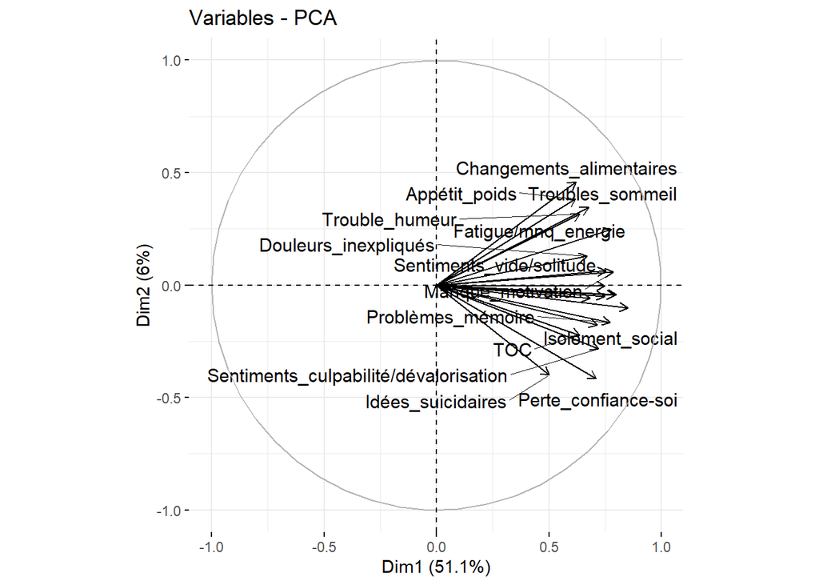

```r
fviz_pca_var(res.pca, repel = T)
```

- La qualité de la représentation dépend de la grandeur cosinus carré, plus il est élevé plus on dit qu’un axe est bien représenté.

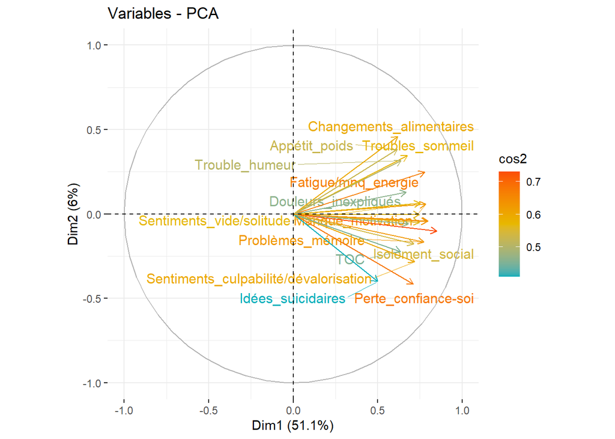

```r
fviz_pca_var(res.pca, col.var = "cos2",
             gradient.cols = c("#00AFBB", "#E7B800", "#FC4E07"),
             repel = T)
```

**Interprétation :**

```r
res.pca$var$cos2
```

```
##                                           Dim.1        Dim.2        Dim.3
## Changements_alimentaires              0.3834742 2.101460e-01 0.0656040159
## Troubles_sommeil                      0.4565017 1.188408e-01 0.0121592838
## Fatigue/mnq_energie                   0.6053504 6.125744e-02 0.0203802127
## Manque_motivation                     0.6151029 3.323197e-03 0.0875627032
## Difficulté_concentration              0.5587955 2.433615e-03 0.1507736964
## Sentiments_culpabilité/dévalorisation 0.5182929 7.975480e-02 0.0106125422
## Perte_confiance-soi                   0.5041598 1.732631e-01 0.0002880285
## Idées_suicidaires                     0.2500128 1.600797e-01 0.0489394120
## Trouble_humeur                        0.4065684 1.004881e-01 0.0002483932
## Agitation/Ralentissement_Psychomoteur 0.4641550 3.282241e-03 0.1190913402
## Sentiments_vide/solitude              0.5647980 4.107292e-03 0.0239315837
## Désintérêt_activités                  0.6372571 1.705640e-03 0.0190327337
## Douleurs_inexpliqués                  0.4471637 1.635977e-02 0.0409216724
## Problèmes_mémoire                     0.5976094 2.755038e-02 0.0434059175
## Sentiments_désespoir                  0.7210894 1.015542e-02 0.0058856374
## Manque_émotions                       0.5577380 9.262775e-06 0.0054492215
## Appétit_poids                         0.3810459 1.469171e-01 0.0820366790
## Isolement_social                      0.5094490 3.125264e-02 0.0146241643
## TOC                                   0.4039754 4.929488e-02 0.3426493347
## Perte_intérêt/plaisir                 0.6290947 2.030809e-03 0.0009391080
##                                              Dim.4       Dim.5        Dim.6
## Changements_alimentaires              0.0632582554 0.009643859 1.236868e-02
## Troubles_sommeil                      0.0339623806 0.102600206 2.950260e-02
## Fatigue/mnq_energie                   0.0009158729 0.075316923 5.476162e-03
## Manque_motivation                     0.0524168397 0.011167361 2.126931e-04
## Difficulté_concentration              0.0059863559 0.015798179 7.509023e-04
## Sentiments_culpabilité/dévalorisation 0.2107620379 0.003942006 7.458790e-03
## Perte_confiance-soi                   0.0572666205 0.008847788 1.226140e-02
## Idées_suicidaires                     0.0768447382 0.025793346 1.968102e-01
## Trouble_humeur                        0.0060135598 0.273346269 2.919726e-02
## Agitation/Ralentissement_Psychomoteur 0.0028441050 0.077556459 7.542235e-03
## Sentiments_vide/solitude              0.0047629430 0.009673259 7.090533e-02
## Désintérêt_activités                  0.0102653912 0.003643453 4.516029e-04
## Douleurs_inexpliqués                  0.1716342087 0.003435193 7.289634e-02
## Problèmes_mémoire                     0.0748872246 0.013637058 1.830297e-05
## Sentiments_désespoir                  0.0113720480 0.009019745 3.033673e-04
## Manque_émotions                       0.1317346239 0.014295089 4.760210e-02
## Appétit_poids                         0.0172711521 0.039673932 1.645676e-02
## Isolement_social                      0.0034354551 0.005371883 1.880452e-01
```

[output cut: 29 more lines]

```
## Sentiments_culpabilité/dévalorisation 1.361464e-02
## Perte_confiance-soi                   8.516945e-04
## Idées_suicidaires                     2.961292e-02
## Trouble_humeur                        3.400398e-04
## Agitation/Ralentissement_Psychomoteur 7.585639e-04
## Sentiments_vide/solitude              2.996990e-03
## Désintérêt_activités                  1.234111e-01
## Douleurs_inexpliqués                  4.522220e-02
## Problèmes_mémoire                     4.289647e-03
## Sentiments_désespoir                  1.344269e-03
## Manque_émotions                       9.072244e-05
## Appétit_poids                         1.862810e-04
## Isolement_social                      1.611801e-03
## TOC                                   6.085270e-02
## Perte_intérêt/plaisir                 1.096920e-02
```

### 4.3. COSINUS² des variables avec les composantes :

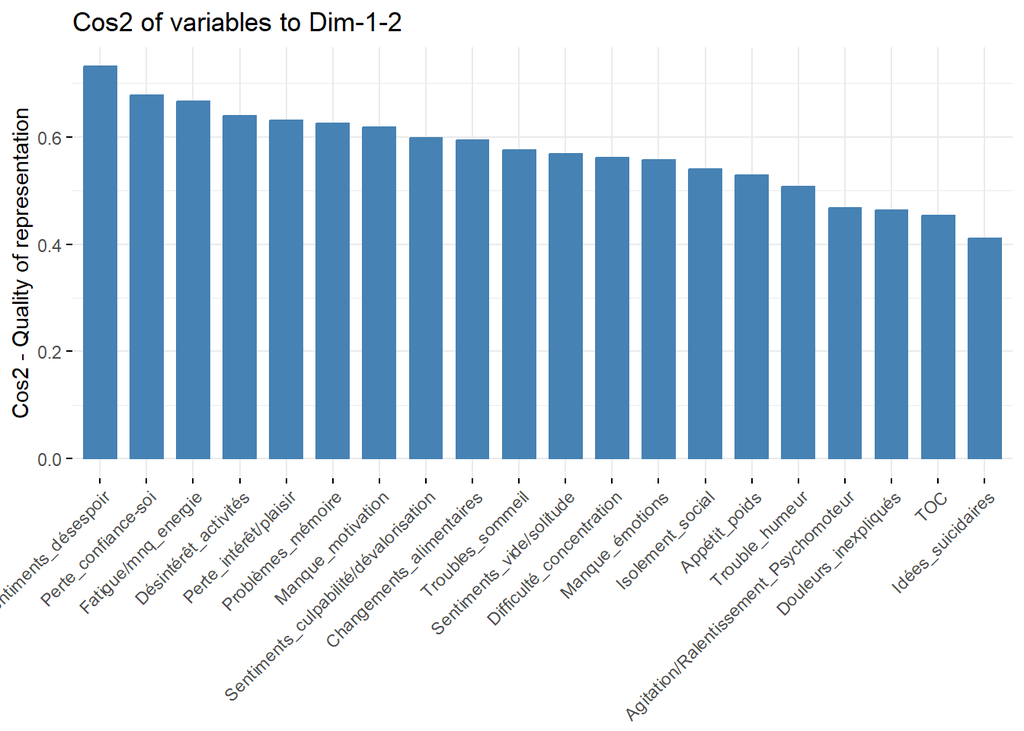

```r
fviz_cos2(res.pca, choice = "var", axes = 1:2)
```

- Les cos² de « Sentiments_désespoir » et « Perte_confiance-Soi » sont élevés ce qui indique une bonne représentation des deux variables sur les axes principaux. Dans ce cas, ces variables sont positionnées à proximité de la circonférence du cercle de corrélation tandis que le cos² de « Idées_Suicidaires » est faible par rapport aux autres variables, d’où la variable est un peu proche du centre du cercle.

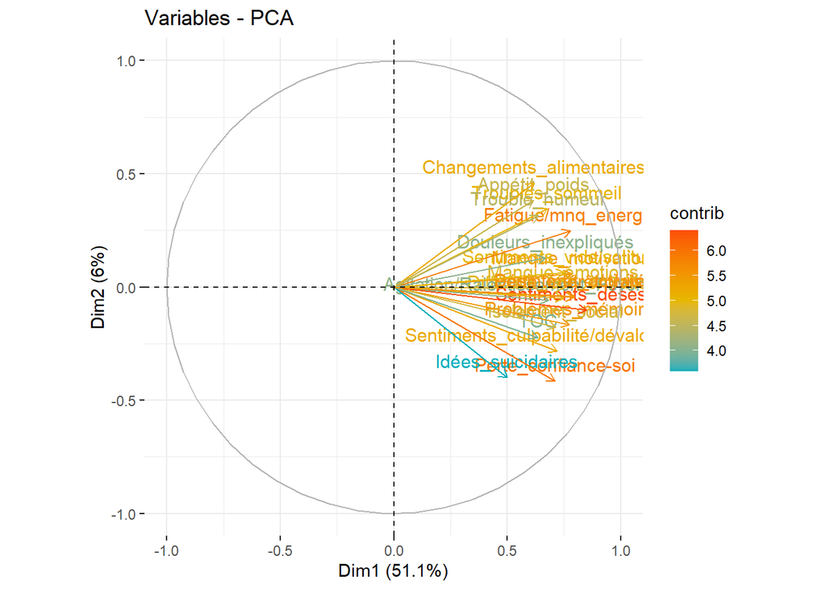

```r
fviz_pca_var(res.pca, col.var = "contrib", gradient.cols = c("#00AFBB", "#E7B800", "#FC4E07"),repel = F)
```

- « Sentiments_désespoir » est la variable **qui contribue le plus** dans la définition des axes principaux.

## 5. Itnterprétation de la carte des individus:

- De la même manière, l’objet ind de res.pca contient les objets : coord, cos2 et contrib.

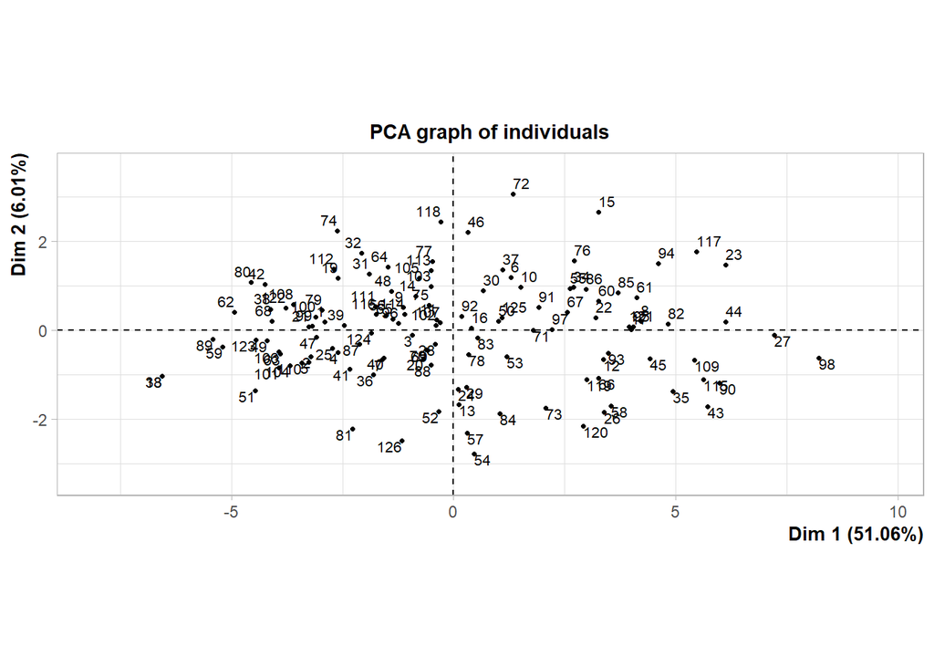

```r
res.pca = PCA(bloc1, graph=F)
plot(res.pca, choix="ind", cex=0.7)
```

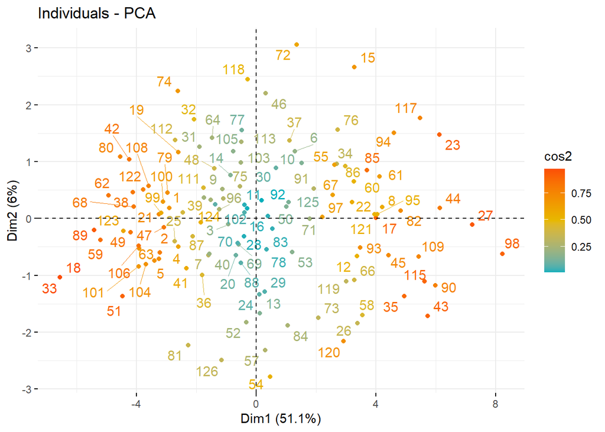

```r
fviz_pca_ind(res.pca, col.ind = "cos2",
             gradient.cols = c("#00AFBB", "#E7B800", "#FC4E07"),
             repel = T)
```

# IV. ACM et son interprétation :

- L’ACM, ou Analyse en Composantes Multiples, est également une technique d’analyse multivariée utilisée pour explorer les relations entre plusieurs variables. Contrairement à l’ACP, l’ACM est utilisée lorsque les variables sont catégorielles et non continues.
- Dans notre contexte, l’objectif de l’Analyse en Composantes Multiples (ACM) pourrait être d’explorer les relations entre nos plusieurs variables catégorielles liées à la dépression, telles que l’âge, le sexe, le niveau d’éducation, la CSP, etc. En appliquant l’ACM, nous pouvons identifier les combinaisons de variables qui sont les plus fréquentes et voir comment elles sont associées à la dépression. Cela peut nous aider à mieux comprendre les facteurs de risque et les symptômes de la dépression chez différents groupes de personnes, ainsi qu’à identifier les tendances et les schémas généraux liés à la dépression.

## 1. But de l’ACM :

```r
bloc3<-df[,2:4]
res.mca <- MCA (bloc3, graph = FALSE)
```

## 2. Visualisation et interprétation :

```r
res.mca$eig
```

```
##       eigenvalue percentage of variance cumulative percentage of variance
## dim 1 0.65774833              21.924944                          21.92494
## dim 2 0.54405431              18.135144                          40.06009
## dim 3 0.43528580              14.509527                          54.56961
## dim 4 0.36477972              12.159324                          66.72894
## dim 5 0.33333333              11.111111                          77.84005
## dim 6 0.27335356               9.111785                          86.95184
## dim 7 0.22739869               7.579956                          94.53179
## dim 8 0.12166131               4.055377                          98.58717
## dim 9 0.04238493               1.412831                         100.00000
```

## 3. Nombre d’axes à retenir :

### 3.1. Critère 1 :

- Retenir les axes dont les valeurs propres sont supérieures à la moyenne soit 1/m = 0.333 donc les 4 premiers axes.

### 3.2. Critère 2 :

- Tracer le graphique des valeurs propres et noter que le coude se trouve au niveau du 3ème axe.

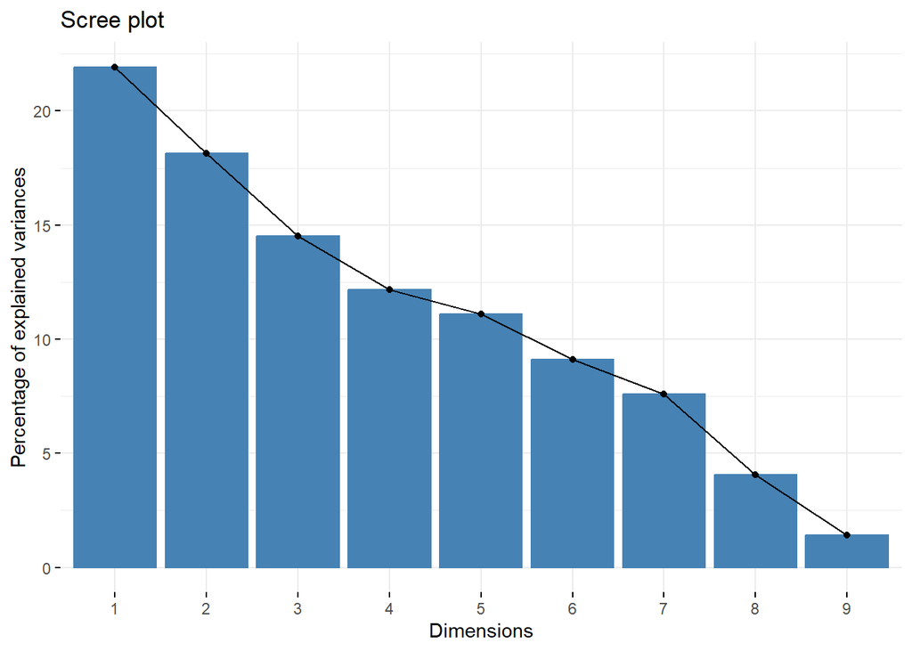

```r
fviz_screeplot(res.mca)
```

### 3.2. Critère 3 :

- Raisonner sur le taux d’inertie cumulé et retenir les 2 premeiers axes qui, sur les 9 axes de l’ACM, accumulent quasi la moitié de l’inertie.

**En conclusion, le choix des 2 premiers axes serait justifié.**

## 4. Interprétation de la première carte des modalités :

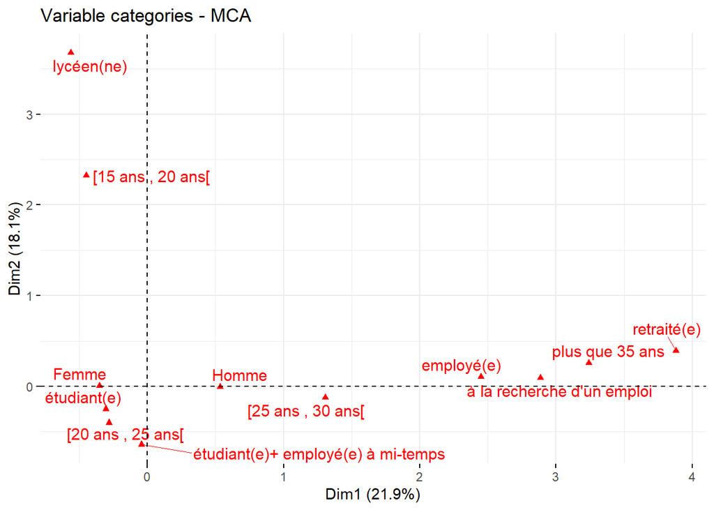

```r
#Représentation de la première carte des modalités
fviz_mca_var (res.mca,
              repel = TRUE,
              ggtheme = theme_minimal ())
```

**Interprétation :**

- La plupart des étudiants de notre échantillon sont des femmes âgées entre 20 et 25 ans, parmi lesquelles certaines travaillent en parallèle de leurs études.
- Les lycéens sont âgés entre 15 et 20 ans.
- Les retraités sont âgés de plus que 35 ans.
- Ceux qui sont entre 25 et 35 sont soit à la recherche d’emploie soit employé.
- on notera aussi que l’âge des étudiants s’oppose à l’âge des retraité.

```r
dimdesc(res.mca, axes=1:2, proba=0.05)$`Dim 1`
```

```
##
## Link between the variable and the categorical variable (1-way anova)
## =============================================
##              R2      p.value
## âge   0.8907553 1.842889e-58
## CSP   0.8941140 9.455490e-57
## genre 0.1883757 3.828980e-07
##
## Link between variable abd the categories of the categorical variables
## ================================================================
##                                  Estimate      p.value
## âge=plus que 35 ans             1.8542619 2.980570e-46
## CSP=employé(e)                  0.8644208 2.196216e-18
## CSP=retraité(e)                 2.0240346 4.605699e-09
## genre=Homme                     0.3597419 3.828980e-07
## CSP=à la recherche d'un emploi  1.2185732 2.421456e-05
## âge=[25 ans , 30 ans[           0.2864395 7.596497e-03
## genre=Femme                    -0.3597419 3.828980e-07
## âge=[20 ans , 25 ans[          -1.0015066 8.331539e-10
## CSP=étudiant(e)                -1.3706085 2.590312e-16
```

## 5. Interprétation de la première carte des individus :

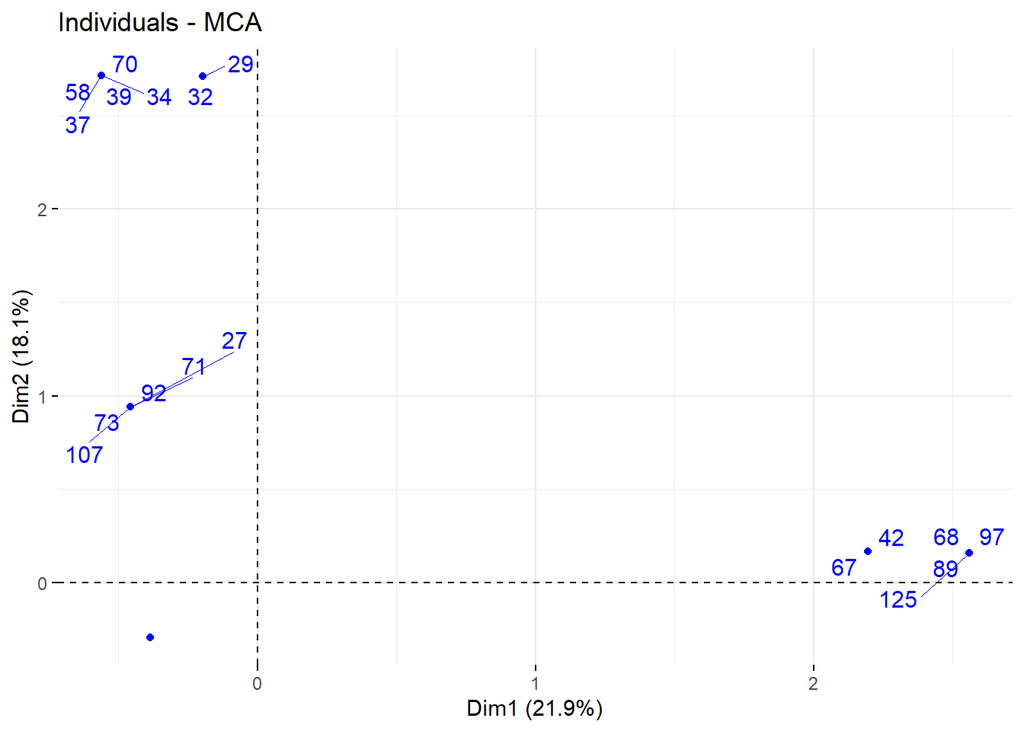

```r
#Représentation de la première carte des individus
fviz_mca_ind (res.mca,select.ind  = list(cos2 = 0.4),
              repel = TRUE,
              ggtheme = theme_minimal ())
```

- Pour interpréter cette carte, on se base sur l’interprétation de la carte des modalités. Ainsi, un groupe des individus dont les numéros sont [42,67,68,89,97,125], situé du coté droit de la carte, serait caractérisé par les modalités “Plus de 35 ans ,employé ,retraité ,à la recherhe d’emploi” qui sont donc les adultes.

**NB:** on a sélectionné les individus dont le cos2 est supérieur à 0.4 pour bien interpréter la carte des individus.

# V. Classification :

## 1. Méthode Hiérarchique :

### 1.1. Arbre Hiérarchique :

#### 1.1.1. Afficher l’arbre :

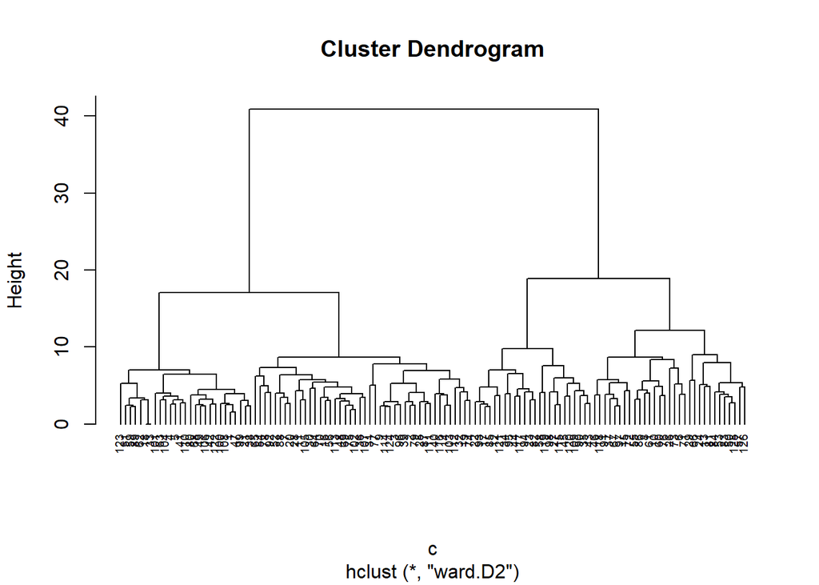

```r
c<-dist(scale(bloc1),method="euclidean")
h<- hclust(c, method="ward.D2")
plot(h, hang = -1, cex =0.6)
```

#### 1.1.2. Choisir Les Classes :

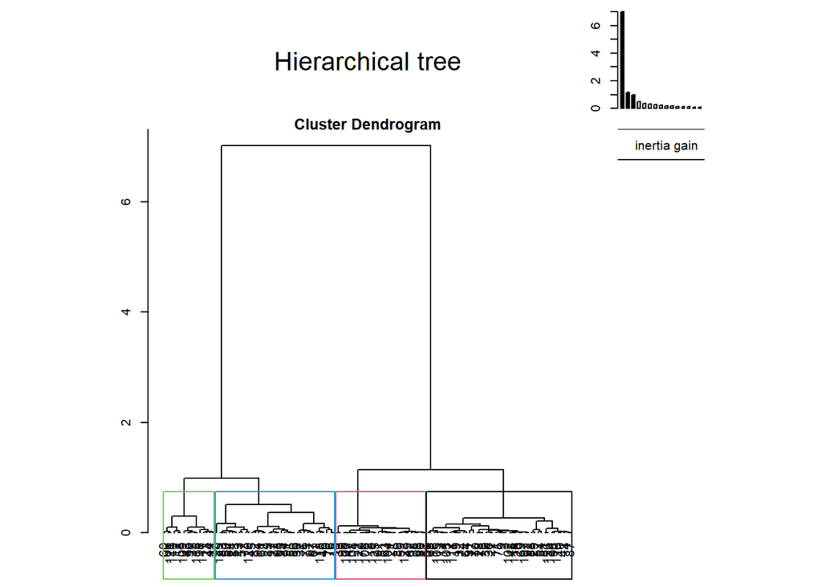

```r
res.HCPC<-HCPC(res.pca, consol=TRUE, graph=F)
plot.HCPC(res.HCPC,choice='tree', title ='Hierarchical tree')
```

**Conclusion :** on peut choisir `4 classes`.

### 1.2. Arbre hiérarchique sur la carte factorielle :

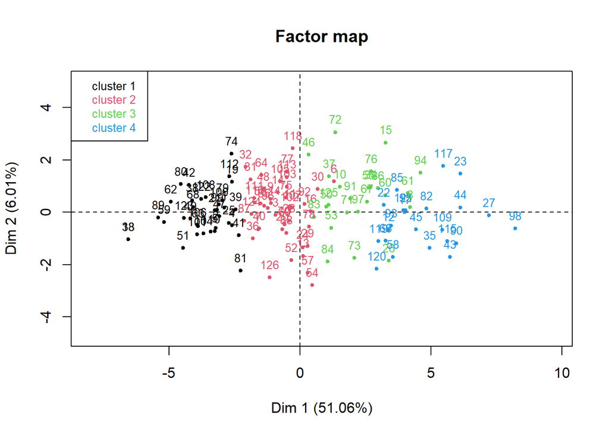

```r
plot.HCPC(res.HCPC, choice = 'map', draw.tree=F, title ='Factor map')
```

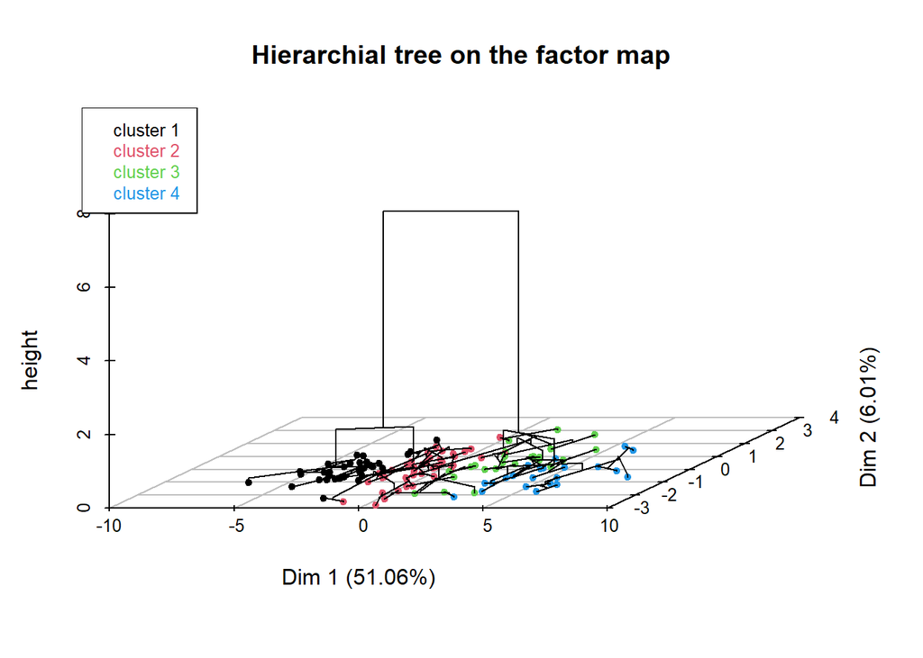

```r
plot.HCPC(res.HCPC,choice = '3D.map', ind.names = FALSE, title='Hierarchial tree on the factor map')
```

## 2. Méthode non Hiérarchique :

### 2.1. K-means :

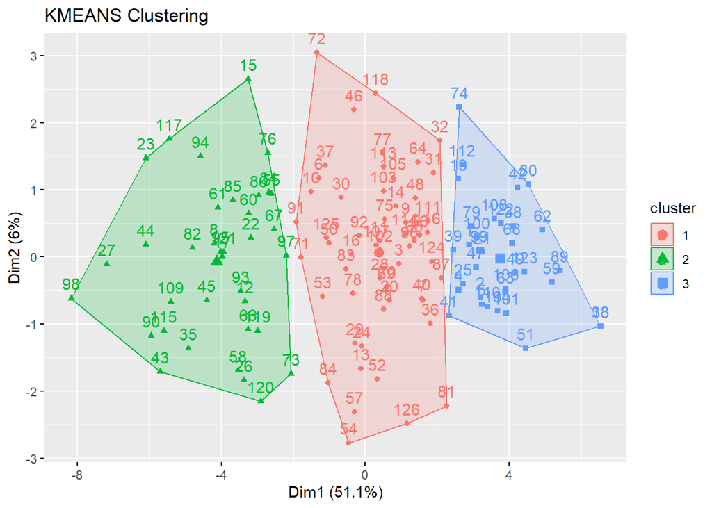

```r
res.km <- eclust(bloc1, "kmeans", nstart = 25)
```

## 3. Description des classes par les variables :

- L’objectif principal de la sortie si dessous est d’aider à interpréter les résultats de l’analyse HAC (analyse de classification hiérarchique), en fournissant une description des variables qui ont contribué à la formation des différents groupes de la classification hiérarchique. Les descriptions de variables sont utiles pour comprendre pourquoi certaines variables ont été regroupées ensemble et pour interpréter les différences entre les groupes.

```r
res.HCPC$desc.var
```

```
##
## Link between the cluster variable and the quantitative variables
## ================================================================
##                                            Eta2      P-value
## Sentiments_désespoir                  0.6554296 4.283756e-28
## Manque_motivation                     0.6030090 2.321908e-24
## Fatigue/mnq_energie                   0.5915393 1.307173e-23
## TOC                                   0.5735410 1.787123e-22
## Désintérêt_activités                  0.5642121 6.636826e-22
## Perte_intérêt/plaisir                 0.5628377 8.032811e-22
## Sentiments_vide/solitude              0.5099220 8.147645e-19
## Perte_confiance-soi                   0.4971336 3.873651e-18
## Difficulté_concentration              0.4953108 4.821743e-18
## Sentiments_culpabilité/dévalorisation 0.4906741 8.385057e-18
## Problèmes_mémoire                     0.4893131 9.854136e-18
## Isolement_social                      0.4849518 1.648235e-17
## Manque_émotions                       0.4844516 1.747902e-17
## Agitation/Ralentissement_Psychomoteur 0.4456460 1.404693e-15
## Appétit_poids                         0.4137745 4.101895e-14
## Troubles_sommeil                      0.4082928 7.190675e-14
## Douleurs_inexpliqués                  0.3942947 2.943848e-13
## Trouble_humeur                        0.3365576 7.047746e-11
## Changements_alimentaires              0.3173368 3.912725e-10
## Idées_suicidaires                     0.2339267 3.835801e-07
##
## Description of each cluster by quantitative variables
## =====================================================
## $`1`
##                                          v.test Mean in category Overall mean
## Idées_suicidaires                     -4.133291       0.05714286    0.6587302
## TOC                                   -4.548692       0.08571429    0.8015873
## Agitation/Ralentissement_Psychomoteur -5.038360       0.34285714    1.2142857
## Troubles_sommeil                      -5.122224       1.14285714    2.0158730
## Manque_émotions                       -5.204091       0.85714286    1.7698413
## Trouble_humeur                        -5.289961       0.85714286    1.7698413
## Changements_alimentaires              -5.362600       1.08571429    1.8809524
## Douleurs_inexpliqués                  -5.370682       0.54285714    1.5317460
## Isolement_social                      -5.496902       0.65714286    1.7301587
## Sentiments_culpabilité/dévalorisation -5.973546       0.60000000    1.7698413
## Sentiments_vide/solitude              -6.019676       0.97142857    2.0793651
```

[output cut: 105 more lines]

```
## Perte_intérêt/plaisir                      0.7777628   1.272022 9.890194e-10
## Manque_émotions                            0.7010659   1.216048 1.059843e-09
## Problèmes_mémoire                          0.7117698   1.312119 1.336930e-08
## Désintérêt_activités                       0.9760845   1.263700 2.305707e-08
## Sentiments_culpabilité/dévalorisation      0.8157245   1.357885 4.683090e-08
## Sentiments_vide/solitude                   0.6419488   1.276175 5.594449e-08
## Fatigue/mnq_energie                        0.4995272   1.105342 6.138438e-08
## Appétit_poids                              0.9284416   1.193145 2.861039e-07
## Troubles_sommeil                           0.7404081   1.181767 6.267404e-07
## Manque_motivation                          0.6735623   1.078431 2.607616e-06
## Trouble_humeur                             1.1287613   1.196308 3.090940e-06
## Douleurs_inexpliqués                       1.1270853   1.276693 3.542203e-06
## Difficulté_concentration                   0.9624323   1.157452 6.034797e-06
## Idées_suicidaires                          1.3471246   1.009186 6.243151e-06
## Changements_alimentaires                   0.9243605   1.028230 4.382927e-04
```

```r
res.HCPC$desc.axes
```

```
##
## Link between the cluster variable and the quantitative variables
## ================================================================
##             Eta2      P-value
## Dim.1 0.88596751 2.515813e-57
## Dim.3 0.25808815 5.687119e-08
## Dim.2 0.07539362 2.227026e-02
##
## Description of each cluster by quantitative variables
## =====================================================
## $`1`
##          v.test Mean in category Overall mean sd in category Overall sd
## Dim.1 -8.078653        -3.723216 1.134487e-14       1.067475   3.195565
##            p.value
## Dim.1 6.548598e-16
##
## $`2`
## NULL
##
## $`3`
##          v.test Mean in category  Overall mean sd in category Overall sd
## Dim.1  3.787599        2.2317783  1.134487e-14      1.1640859   3.195565
## Dim.2  2.667251        0.5392636  2.629393e-15      1.2318973   1.096473
## Dim.3 -5.183320       -0.9999134 -2.463252e-15      0.8999087   1.046201
##            p.value
## Dim.1 1.521103e-04
## Dim.2 7.647452e-03
## Dim.3 2.179711e-07
##
## $`4`
##          v.test Mean in category  Overall mean sd in category Overall sd
## Dim.1  7.802417        4.7192881  1.134487e-14      1.3991645   3.195565
## Dim.3  3.411320        0.6755183 -2.463252e-15      0.9654096   1.046201
## Dim.2 -2.052127       -0.4258942  2.629393e-15      0.9640277   1.096473
##            p.value
## Dim.1 6.073241e-15
## Dim.3 6.464915e-04
## Dim.2 4.015734e-02
```

## 4. Classification Automatique :

### 4.1. Silhouette :

```
##   cluster size ave.sil.width
## 1       1   56          0.06
## 2       2   36          0.24
## 3       3   34          0.32
```

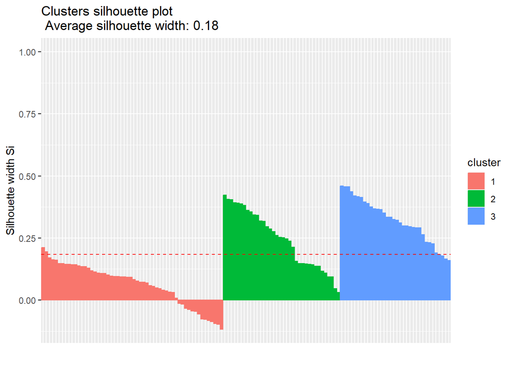

```r
fviz_silhouette(res.km)
```